# K vecinos más cercanos: predecir preguntándole a los parecidos

Machine Learning · Clasificación (1 de 5) · UTB 2026-II

Jorge Luis Villalba Acevedo

2026-09-15

# ¿Sabías que…?

## El algoritmo más simple del mundo

Un banco quiere saber si usted va a pagar su crédito.

KNN responde así: **busca a los 25 clientes más parecidos a usted** y mira qué hicieron ellos.

No hay ecuación que ajustar. No hay entrenamiento. Solo **memoria y distancia**.

## Objetivos

1. **Entender** la regla de KNN: distancia, vecindario y voto.
2. **Formalizar** la distancia euclidiana y la regla de decisión.
3. **Ver** el efecto de $k$ en la frontera: de memorizar a aplanar.
4. **Comprobar** por qué KNN **exige escalar** las variables.
5. **Elegir** $k$ con criterio, mirando el conjunto de prueba.

# Preparación replicable

## Todo lo que necesita para seguir la clase

```python
import numpy as np
import pandas as pd
from sklearn.neighbors import KNeighborsClassifier
from sklearn.preprocessing import StandardScaler

SEMILLA = 42
rng = np.random.default_rng(SEMILLA)

# Cartera de creditos de consumo de un banco: 600 clientes con credito vigente
n = 600
ingreso = np.round(np.exp(rng.normal(np.log(3.2), 0.45, n)), 2)   # millones/mes
razon   = np.clip(np.round(rng.beta(2.2, 4.5, n) * 0.9, 3), 0.02, 0.85)  # deuda/ingreso
eta     = -2.4 - 1.8 * np.log(ingreso) + 10.5 * razon
mora    = rng.binomial(1, 1 / (1 + np.exp(-eta)))   # 1 = cayo en mora > 90 dias

df = pd.DataFrame({"ingreso": ingreso, "razon_deuda": razon, "mora": mora})

# Particion determinista: primer 70 % (la regla del curso)
n_train = int(np.floor(0.70 * n))
tr, te = df.iloc[:n_train], df.iloc[n_train:]
X_cols = ["ingreso", "razon_deuda"]
Xtr, ytr = tr[X_cols].to_numpy(), tr["mora"].to_numpy()
Xte, yte = te[X_cols].to_numpy(), te["mora"].to_numpy()

print(f"{n} clientes · tasa de mora {df['mora'].mean():.3f} · "
      f"entrenamiento {len(tr)} · prueba {len(te)}")
```

```
600 clientes · tasa de mora 0.310 · entrenamiento 420 · prueba 180
```

**Copie este chunk y corra la clase entera.** Misma semilla, mismos números.

## El mapa: así se ve la cartera

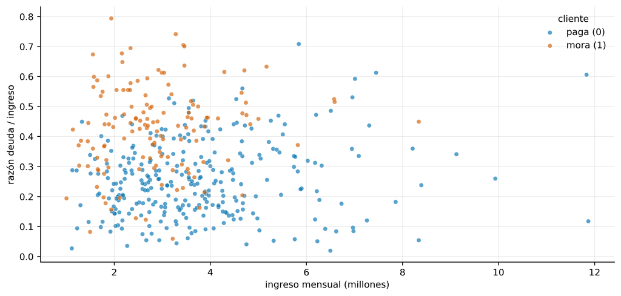

Figura 1: Cada punto es un cliente. Azul paga, rojo cae en mora. No hay una línea obvia que los separe, pero hay ZONAS.

# La regla

## Para niños: pregúntele a los vecinos

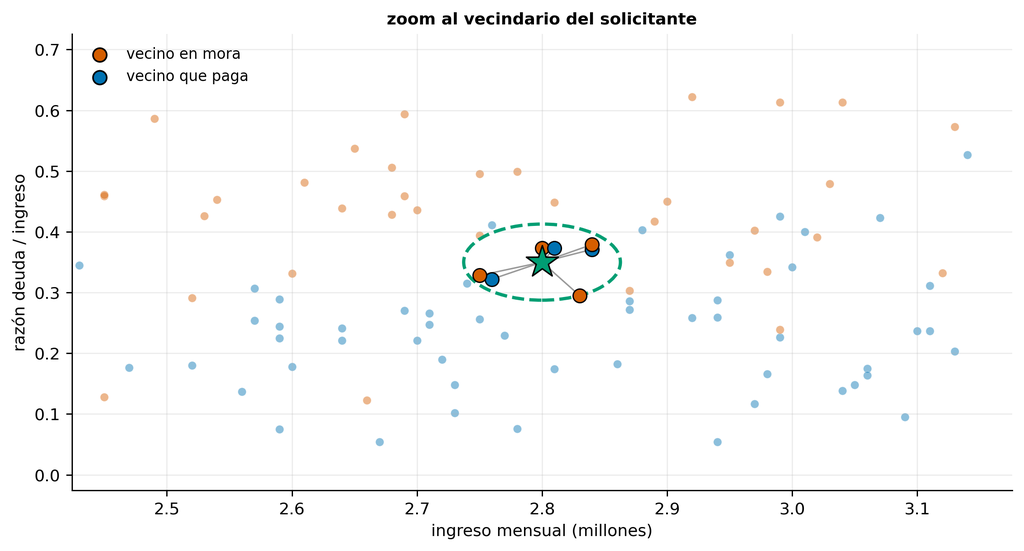

Figura 2: Un solicitante nuevo (estrella). Sus 7 vecinos más cercanos votan: gana la mayoría.

```
Vecinos en mora: 4 de 7  ->  decisión: MORA (1)
Probabilidad estimada = 4/7 = 0.571
```

## La métrica de distancia

Con $x, z \in \mathbb{R}^n$, las tres distancias que hay que conocer:

$$d_{\text{euclídea}}(x,z) = \sqrt{\sum_{j=1}^{n}(x_j - z_j)^2},
\qquad
d_{\text{Manhattan}}(x,z) = \sum_{j=1}^{n}\lvert x_j - z_j\rvert
\tag{1}$$

Las dos son casos particulares de la distancia de **Minkowski** de orden $p$:

$$d_p(x,z) = \Bigl(\sum_{j=1}^{n} \lvert x_j - z_j \rvert^{\,p}\Bigr)^{1/p}
\tag{2}$$

Con $p=2$ se recupera la euclídea y con $p=1$ la Manhattan. En scikit-learn eso es literalmente el argumento `p` de `KNeighborsClassifier`, cuyo defecto es `metric="minkowski", p=2`.

```
A: euclídea = 3.1623   Manhattan = 4.0000
B: euclídea = 3.1113   Manhattan = 4.4000
```

El vecino más cercano de la consulta es **B** bajo la métrica euclídea (3,111 contra 3,162) y **A** bajo Manhattan (4,0 contra 4,4). Con $k=1$, cambiar la métrica cambia la predicción: no es un detalle cosmético. Manhattan suele portarse mejor en dimensión alta y con variables que no son comparables entre sí; la euclídea es el defecto razonable.

## Con rigor: la distancia euclidiana

La única matemática que KNN necesita es **medir parecido**. Entre dos clientes $x$ y $z$ con $p$ variables:

$$d(x, z) \;=\; \sqrt{\sum_{j=1}^{p} (x_j - z_j)^2}$$

Con nuestras dos variables, es el teorema de Pitágoras:

$$d \;=\; \sqrt{(\text{ingreso}_x - \text{ingreso}_z)^2 + (\text{razón}_x - \text{razón}_z)^2}$$

**La regla de decisión formal.** Sea $N_k(x)$ el conjunto de los $k$ vecinos más cercanos a $x$ en el entrenamiento. La probabilidad estimada y la clase son (James et al. 2023):
$$\hat{P}(y = 1 \mid x) = \frac{1}{k}\sum_{i \in N_k(x)} y_i
\qquad\qquad
\hat{y} = \begin{cases} 1 & \text{si } \hat{P} \geq 0.5\\ 0 & \text{si no}\end{cases}$$

## Las dos vías: KNN a mano y con la librería

```python
# Via 1, a mano: distancia, ordenar, votar
def knn_a_mano(X_ent, y_ent, x_nuevo, k):
    d = np.sqrt(((X_ent - x_nuevo) ** 2).sum(axis=1))   # distancia a todos
    vecinos = np.argsort(d)[:k]                          # los k mas cercanos
    return y_ent[vecinos].mean()                         # proporcion de votos

p_mano = knn_a_mano(Xtr, ytr, nuevo, 7)

# Via 2, la libreria:
modelo7 = KNeighborsClassifier(n_neighbors=7).fit(Xtr, ytr)
p_lib = modelo7.predict_proba(nuevo.reshape(1, -1))[0, 1]

print(f"a mano  = {num(p_mano)}")
print(f"sklearn = {num(p_lib)}")
assert abs(p_mano - p_lib) < 1e-12
print("Idénticas: la librería hace exactamente la cuenta del dibujo.")
```

```
a mano  = 0.571
sklearn = 0.571
Idénticas: la librería hace exactamente la cuenta del dibujo.
```

# El parámetro que lo cambia todo: $k$

## De memorizar a aplanar

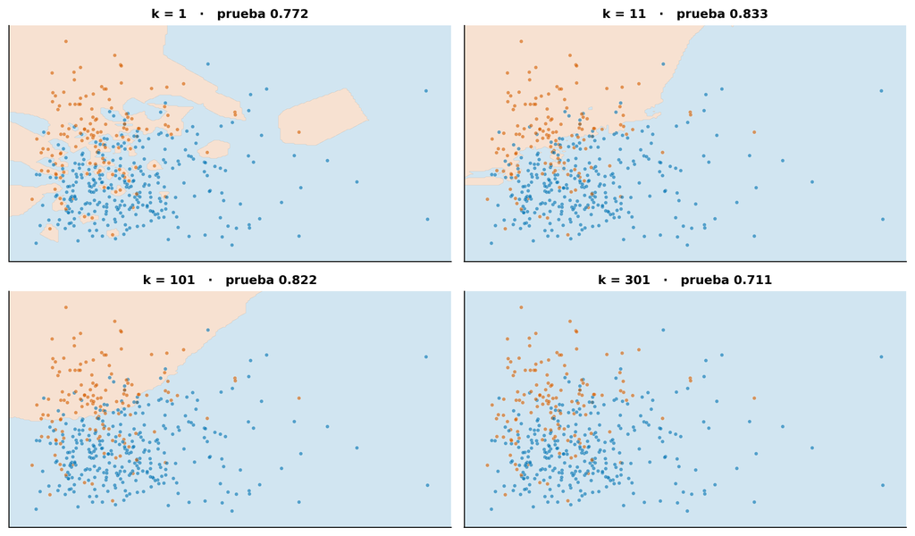

Figura 3: Frontera de decisión para cuatro valores de k (variables escaladas). k=1 memoriza cada cliente; k=301 borra la frontera y predice siempre la clase mayoritaria.

## $k$ es el mismo dilema de siempre

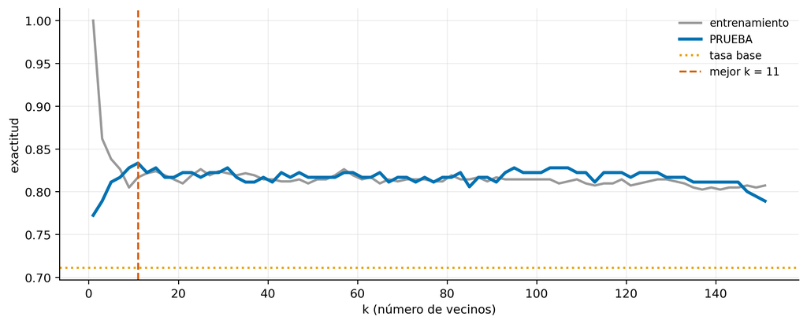

Figura 4: Exactitud en entrenamiento y prueba contra k. La de entrenamiento es perfecta en k=1 y engaña; la de prueba tiene un óptimo.

```
mejor k = 11 · exactitud prueba = 0.833 · tasa base = 0.711
```

# La trampa de KNN

## Si no escala, una variable se come a la otra

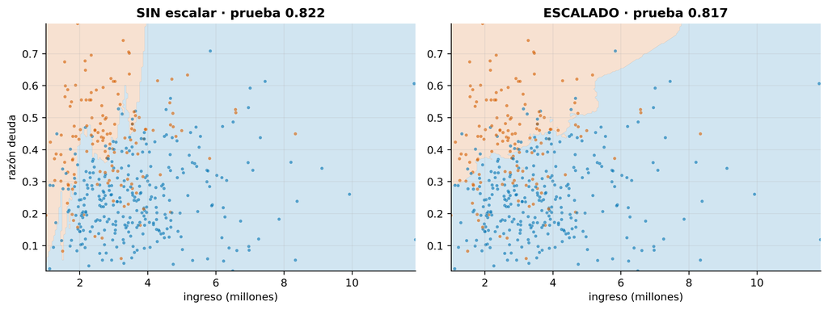

Figura 5: Mismo k = 25. Izquierda: sin escalar, el ingreso (que va de 0.8 a 12) domina la distancia y la frontera se vuelve vertical. Derecha: escalado, las dos variables cuentan.

**Por qué pasa:** en la fórmula de la distancia, una diferencia de 2 millones de ingreso aporta $2^2 = 4$, mientras que una diferencia de 0.3 en la razón de deuda aporta $0.3^2 = 0.09$. **La variable de números grandes decide quién es vecino**, aunque sea la menos informativa.

```python
a, b = Xtr[0], Xtr[1]           # dos clientes cualesquiera
print(f"cliente A: ingreso {a[0]}, razón {a[1]}")
print(f"cliente B: ingreso {b[0]}, razón {b[1]}")
print(f"  aporte del ingreso a la distancia² : {(a[0]-b[0])**2:.4f}")
print(f"  aporte de la razón  a la distancia²: {(a[1]-b[1])**2:.4f}")
```

```
cliente A: ingreso 3.67, razón 0.239
cliente B: ingreso 2.0, razón 0.144
  aporte del ingreso a la distancia² : 2.7889
  aporte de la razón  a la distancia²: 0.0090
```

## El experimento que lo demuestra: la misma información, otras unidades

```python
# EXACTAMENTE los mismos clientes; solo cambia la UNIDAD del ingreso
for nombre, columna in [("millones", Xtr[:, 0]),
                        ("miles", Xtr[:, 0] * 1e3),
                        ("pesos", Xtr[:, 0] * 1e6)]:
    Xa = np.c_[columna, Xtr[:, 1]]
    Xb = np.c_[Xte[:, 0] * (columna[0] / Xtr[0, 0]), Xte[:, 1]]
    m = KNeighborsClassifier(25).fit(Xa, ytr)
    print(f"ingreso en {nombre:9s} -> exactitud en prueba {m.score(Xb, yte):.3f}")
print(f"tasa base (predecir siempre la mayoritaria): {base_te:.3f}")
```

```
ingreso en millones  -> exactitud en prueba 0.822
ingreso en miles     -> exactitud en prueba 0.722
ingreso en pesos     -> exactitud en prueba 0.722
tasa base (predecir siempre la mayoritaria): 0.711
```

El dato no cambió: cambió la unidad. En pesos, el ingreso aplasta a la razón de deuda y la exactitud **se desploma hasta la tasa base**: el modelo dejó de aprender. Escalar no es cosmética.

## Las dos debilidades que hay que decir en voz alta

1. **No hay entrenamiento, pero la predicción es cara.** Cada predicción calcula la distancia a *todos* los clientes guardados: $O(n \cdot p)$. Con millones de registros, KNN es lento justo cuando más se necesita.
2. **La maldición de la dimensionalidad.** Con muchas variables, *todos* los puntos quedan lejos unos de otros y “vecino” pierde sentido (Hastie, Tibshirani, y Friedman 2009).

```python
# Distancia media entre puntos aleatorios al aumentar la dimensión
for p in [2, 10, 50, 200]:
    Z = rng.random((400, p))
    d = np.sqrt(((Z[:200] - Z[200:]) ** 2).sum(axis=1))
    print(f"p = {p:3d} variables · distancia media {d.mean():.2f} · "
          f"razón cercano/lejano {d.min()/d.max():.3f}")
```

```
p =   2 variables · distancia media 0.50 · razón cercano/lejano 0.011
p =  10 variables · distancia media 1.24 · razón cercano/lejano 0.304
p =  50 variables · distancia media 2.88 · razón cercano/lejano 0.633
p = 200 variables · distancia media 5.74 · razón cercano/lejano 0.797
```

# Cierre

## Tres ideas para llevarse

1. KNN no ajusta nada: **guarda los datos y pregunta a los $k$ parecidos**; la proporción de votos ya es una probabilidad.
2. **$k$ es un hiperparámetro** con el dilema de siempre: chico memoriza, grande aplana; se elige mirando la prueba, no el entrenamiento.
3. **Escalar no es opcional** en KNN: la distancia la decide la variable de números grandes si no se interviene.

## Resumen consolidado

| Cifra | Valor |
| --- | --- |
| Clientes (entrenamiento / prueba) | 420 / 180 |
| Tasa de mora de la cartera | 0.310 |
| Tasa base de la prueba | 0.711 |
| Mejor k (por prueba, escalado) | 11 |
| Exactitud con ese k | 0.833 |
| Exactitud k = 25 SIN escalar | 0.822 |
| Semilla | 42 |

## Referencias

Hastie, Trevor, Robert Tibshirani, y Jerome Friedman. 2009. *The Elements of Statistical Learning*. 2.ª ed. Springer.

James, Gareth, Daniela Witten, Trevor Hastie, Robert Tibshirani, y Jonathan Taylor. 2023. *An Introduction to Statistical Learning: with Applications in Python*. Springer.